# Lesson 9

Timothy Luna

8/23/2019

# 2B-L2 Hough [^1] Transform: Circles

## Intro

Now that we know how to parameterize a line, how do we parameterize a circle?

A circle has a center $(a,b)$ and a radius $r:r^2 = (x_i-a)^2 + (y_i-b)^2$ and these can be used to parameterize the circle.

A circle with a fixed radius r and an unknown gradient direction can be described in Hough space by sampling points from the circle; the Hough space is parameterized by a and b.

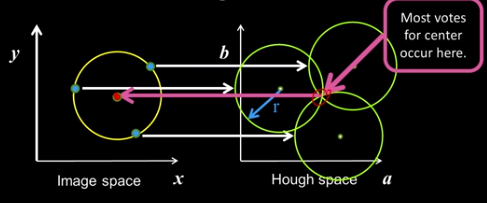

*Any* point on a circle in image space represents a point in Hough space and if the center of the circle is unknown then the point in Hough space is the center point of a circle described by radius r. That circle in Hough space describes a ring of *possible* center points of infinitely many circles that this point could lie on which are r away from the center point. Given many points in image space that lie on a *single* circle they will all describe circles in Hough space. The point where the circles in Hough space cross (the highest number of votes) is the most likely centerpoint of the circle described by the points in the image space.

## Detecting Circles With Hough

There is an example given of a bowling ball moving down a lane with both the ball and ‘moving’ bits marked. The ball is marked with a plus sign while the ball and reflection are marked with bounding box.

The bottom line is that it found a circle.

How to find quarters? Use the radius of a quarter! Note that the same thing that happened with pennies / nickels before now happens with quarters / smaller coins. though slightly different.

## Hough Transform for Circles

Suppose the radius of the circle is unknown and there is no gradient?

Hough space is now parameterized by three dimensions a, b, and r, since r is unknown. The circle is represented in this three-dimensional Hough space via a cone. Voting in this 3-d space won’t work so well because of a dimensionality problem.

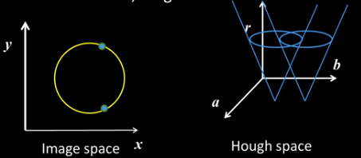

One way to limit the votes is by using the gradient direction. Adding the gradient to the requirements that the points in Hough space must satisfy reduces the set of possible points immensely!

An unknown r *with a known gradient* now limits the Hough space candidates to a single line of ‘voting candidates’.

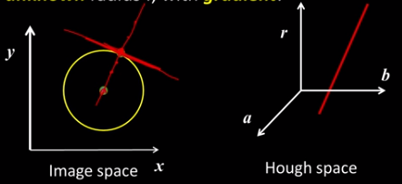

## Algorithm for Circles

1. For every edge pixel (x,y):
2. For each possible radius value r:

3. ```
   For each possible gradient direction $\theta$:
     %% or use estimated gradient
   ```

4. ```
       a = x-rcos(theta)
   ```

5. ```
       b = y + r sin (theta)
   ```

6. ```
       H[a,b,r]+=1
   ```

The discretization is *immensely* important now; the number of possible bins is characterized by $n^d$. If you wanted 100 buckets that’s reasonable in one dimension. In two dimensions that equates to 10,000 buckets. In three dimensions that is *1,000,000 buckets*. High dimensionality is a significant challenge when using a Hough transform.

## Voting Practical Tips

1. Minimize irrelevant tokens (votes) first by taking only edge points with significant gradient magnitude.
2. Choose a *good* grid / discretization; a too coarse discretization will cause buckets to over populate and cause false positives and if it is too fine then points will get lost as their votes are spread across multiple bins.
3. Add votes into neighboring bins (like smoothing in the accumulator array.)
4. Use the direction of the edge to reduce the free parameters by 1.
5. To read back which points voted for ‘winning’ peaks keep tabs on the votes.

## Pros and Cons

Advantages:

- Because all points are processed independently occlusion doesn’t matter.
- There is a fair amount of robustness with respect to noise; noise is unlikely to contribute consistenty to a sigle bin.
- A Hough transform can detect multiple instances of a model in a single pass.

Disdvantages:

- The complexity of the search time increases exponentially with the number of model parameters. Typically people don’t ever use more than three at *maximum*.
- Non target shapes which are similar can produce spurious peaks in parameter space (ellipse vs circle).
- A good quantization can be hard to nail down and requires experimentation
[^1]: https://docs.opencv.org/4.0.0/d4/d70/tutorial_hough_circle.html, https://docs.opencv.org/4.0.0/dd/d1a/group__imgproc__feature.html#ga47849c3be0d0406ad3ca45db65a25d2d